# Loan Data Exploration

## Preliminary Wrangling

This document explores a dataset containing information on Loan applications.

### What is the structure of your dataset?

34 x 113937 List loan data for various loan seekers.

### What is/are the main feature(s) of interest in your dataset?

The main feature of interest is Occupation and what is the average loan amount by profession.

Additional features of interest are to identify groups by Income Range, Credit Grade and or Employment Status. I want to see which of these groups are in the majority in this data set. This could be useful information to a banking organization to determine potential clients to target based on the data from this set. We can determine the average Income Range of an applicant and market specific loans that fit their needs and budgets.

### What features in the dataset do you think will help support your investigation into your feature(s) of interest?

Occupation listing and Employment Status. Also, details of the loan like Term and Borrower APR.

## Univariate Exploration

I want to move freely thru exploring different variables before norrowing down a focus. However I will review variables individually while considering their possible correlation to Occupation.

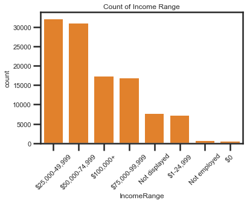

```python
income_order = loan_CL['IncomeRange'].value_counts().index

sb.countplot(data = loan_CL, x = 'IncomeRange', color = base_color, order = income_order)
plt.title('Count of Income Range')
plt.xticks(rotation = 45);
```

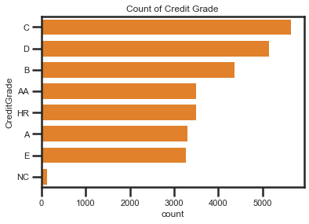

```python
credit_grade = loan_CL['CreditGrade'].value_counts().index

sb.countplot(data = loan_CL, y = 'CreditGrade', color = base_color, order = credit_grade)
plt.title('Count of Credit Grade');
```

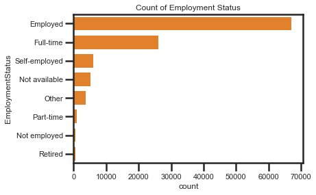

```python
emp_status = loan_CL['EmploymentStatus'].value_counts().index

sb.countplot(data = loan_CL, y = 'EmploymentStatus', color = base_color, order = emp_status)
plt.title('Count of Employment Status');
```

Now I’m looking at top five loan seekers. I also want to see the bottom five. This will give me an idea of what professions are seeking loans and could be a point of interest to a banking organization.

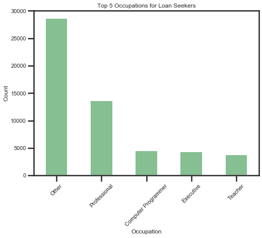

```python
top_five_jobs = loan_CL.Occupation.value_counts().head(5)
top_five_jobs.plot(kind='bar', figsize=(8, 6), color='#86bf91', zorder=2, width=0.5, title='Top 5 Occupations for Loan Seekers')
plt.xticks(rotation = 45)
plt.xlabel('Occupation')
plt.ylabel('Count');
```

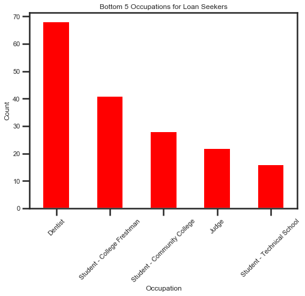

```python
last_five_jobs = loan_CL.Occupation.value_counts().tail(5)
last_five_jobs.plot(kind='bar', figsize=(8, 6), color='red', zorder=2, width=0.5, title='Bottom 5 Occupations for Loan Seekers')
plt.xticks(rotation = 45)
plt.xlabel('Occupation')
plt.ylabel('Count');
```

### Discuss the distribution(s) of your variable(s) of interest. Were there any unusual points? Did you need to perform any transformations?

Occupation is a healthy list of 67 titles. Unfortunately, there is a variable for “Other”, which is understandable, but it is also the largest variable in the set. So, that is vague and may create outliers which cannot be identified. I do not need to create any transformations at this time.

### Of the features you investigated, were there any unusual distributions? Did you perform any operations on the data to tidy, adjust, or change the form of the data? If so, why did you do this?

One unusual distribution was in Term of loan. I had theorized that more loans would be towards the higher Term of 60, when in fact the maximum count is towards 36. Initially, Term was an integer and I changed it to a category. This is more appropriate in this case since we do not want to perform aggregation to the Term variable. It is a Qualitative variable that I would classify as Ordinal data.

Yes, I made some changes. I dropped columns I did not want to use for my analysis. I did this to keep my queries organized and not get distracted by data I would not use. If further in the analysis I determined I dropped information that could be useful, I can always reload the original csv file. However, I reviewed the Prosper Loan Data – Variable Definitions very carefully to determine what I would require. As a bonus I reduced the original data frame from 68.1 mb to 28.9 mb.

## Bivariate Exploration

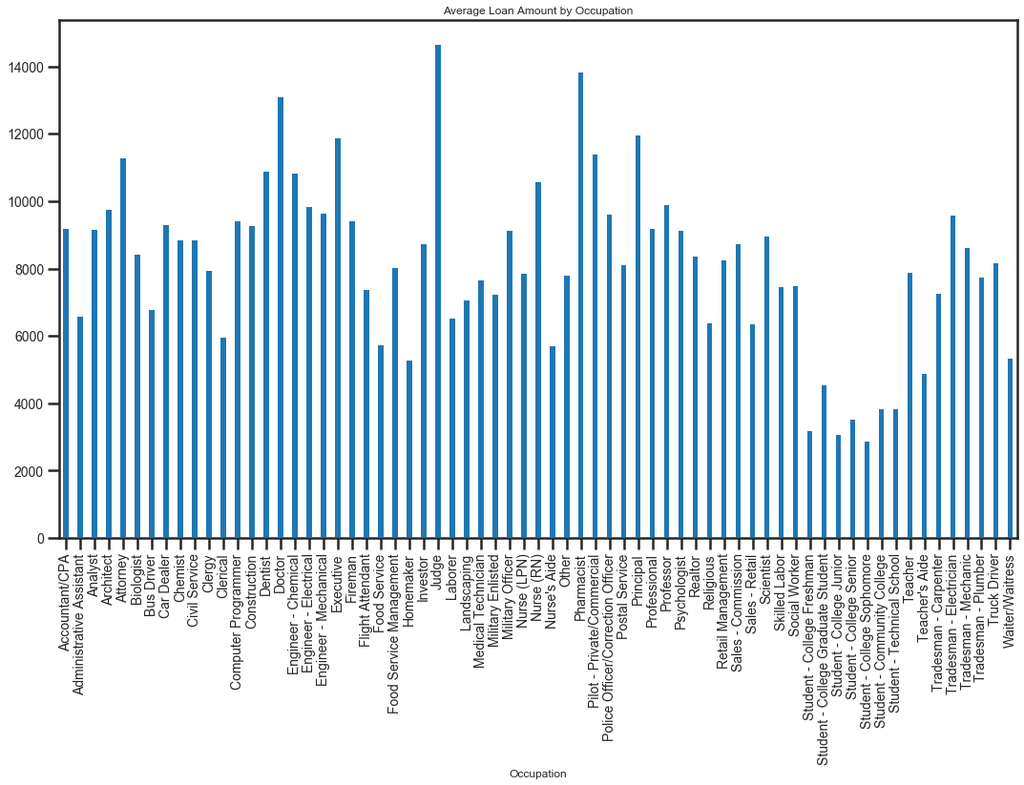

```python
Occs.plot(kind='bar', fontsize= 14, figsize = (18, 10))
plt.title('Average Loan Amount by Occupation');
```

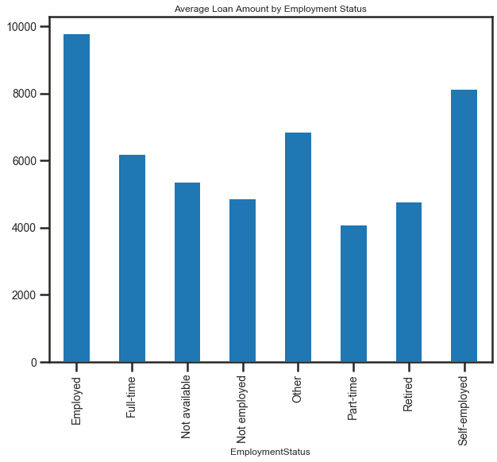

```python
emp_stats = loan_CL.groupby('EmploymentStatus')['LoanOriginalAmount'].mean()
emp_stats.plot(kind='bar', title='Average Loan Amount by Employment Status', fontsize= 14, figsize = (10, 8));
```

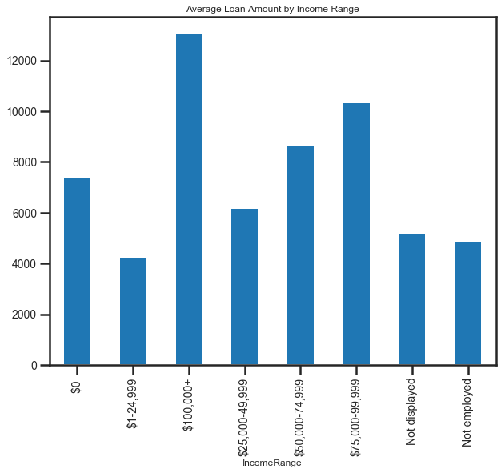

```python
income_stats = loan_CL.groupby('IncomeRange')['LoanOriginalAmount'].mean()
income_stats.plot(kind='bar', title='Average Loan Amount by Income Range', fontsize= 14, figsize = (10, 8));
```

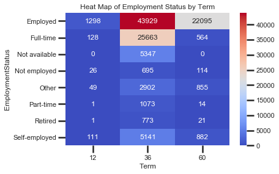

```python
sb.heatmap(emp_counts, annot = True, fmt = 'd', cmap = 'coolwarm')
plt.title('Heat Map of Employment Status by Term');
```

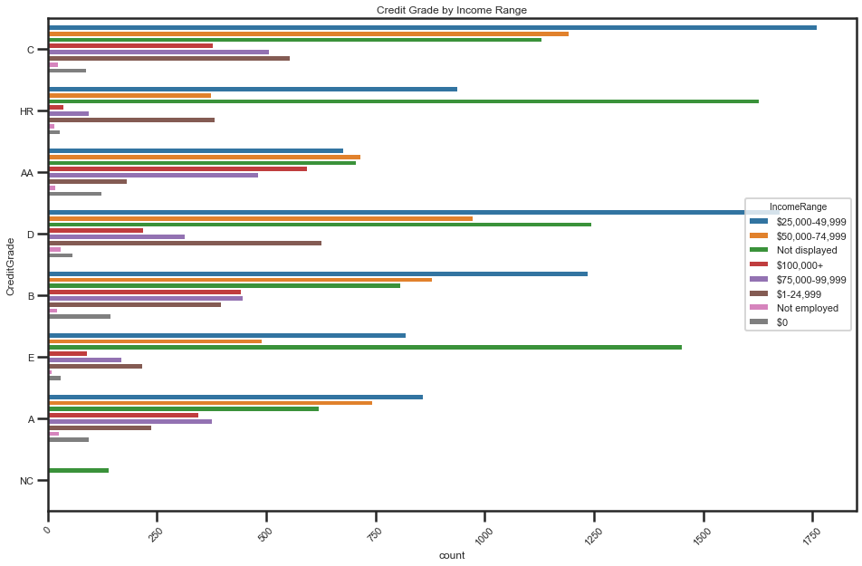

```python
plt.figure(figsize=(16,10))
sb.countplot(data = loan_CL, y ='CreditGrade', hue = 'IncomeRange')
plt.title('Credit Grade by Income Range')
plt.xticks(rotation = 45);
```

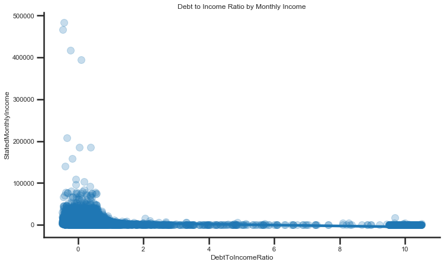

```python
sb.set_style('ticks')
sb.set_context("poster", font_scale = .5)
fig, ax = plt.subplots()
ax.set_title('Debt to Income Ratio by Monthly Income')
fig.set_size_inches(12, 7)
sb.regplot(data = loan_CL, x='DebtToIncomeRatio', y='StatedMonthlyIncome', x_jitter = 0.5,
              scatter_kws = {'alpha' : 1/4} )
sb.despine();
```

## Multivariate Exploration

Here I want to explore BorrowerRate, APR, and LenderYield along with other factors that effect a loan applications. In my conclusion I want to explore categories by IncomeRange. IncomeRange is set as a category and gives me a nice measuring point to explore statistics of my data set.

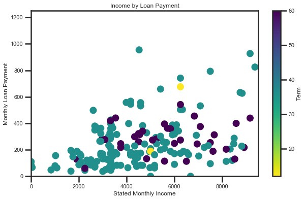

```python
plt.figure(figsize = [10,6])
plt.scatter(data = loan_CL_subset, x = 'StatedMonthlyIncome', y = 'MonthlyLoanPayment', c = 'Term', cmap = 'viridis_r')

plt.colorbar(label = 'Term')
plt.xlim(0,9500)
plt.ylim(0,1250)
plt.title('Income by Loan Payment')
plt.xlabel('Stated Monthly Income')
plt.ylabel('Monthly Loan Payment');
```

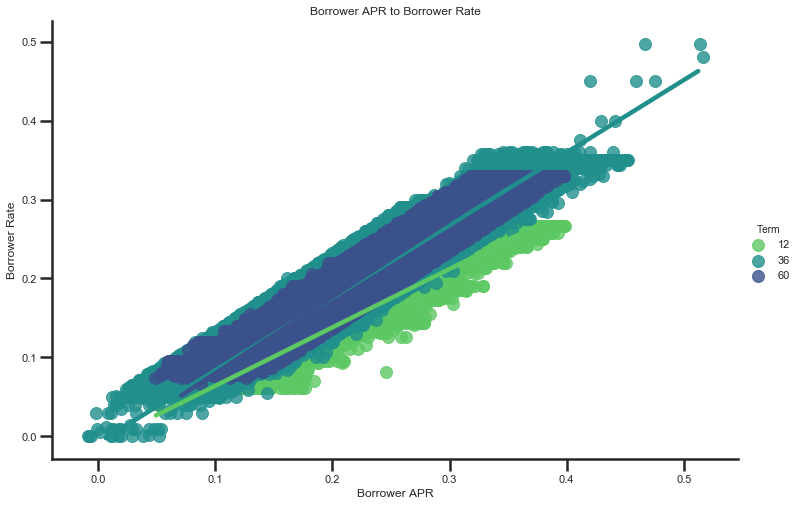

```python
g = sb.FacetGrid(data = loan_CL, hue = 'Term',
                height = 7, aspect = 1.5, palette = 'viridis_r')
g = g.map(sb.regplot, 'BorrowerAPR', 'BorrowerRate', x_jitter = 0.04);
g.add_legend()
plt.xlabel('Borrower APR')
plt.title('Borrower APR to Borrower Rate')
plt.ylabel('Borrower Rate');
```

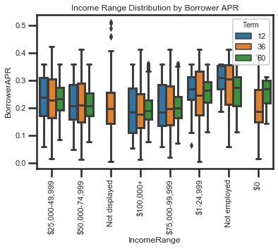

```python
sb.boxplot(data = loan_CL, x = 'IncomeRange', y = 'BorrowerAPR', hue = 'Term');
plt.title('Income Range Distribution by Borrower APR')
plt.xticks(rotation = 90);
```

## Conclusion

Originally, I sought to identify the average loan amount by occupation. As I dive deeper in my analysis, I sought to narrow the categories down to by employment status and income range.

Listing by income range would be a more general category and it is a major factor for loan applicants. This could be used as a baseline for what loan amount an applicant may qualify for.